```
 [1] "channel"   "db.oocyte" "g3.g"      "g3.h"      "g3.oocyte" "g3.sf"     "my.stderr"
 [8] "sb.g"      "sb.h"      "sb.sf"     "sql"       "sr.g"      "sr.h"      "sr.sf"
[15] "stderr"
```

# The project

Between 1988 and early 1992, Warwick Nash and team took monthly samples (~ 12 females) of abalone from George III Rock as part of a study on spawning periodicity. During the last year of sampling (1991), monthly samples were also taken at Shag Rock bay and Stinking Bay on the Tasman Peninsular. Morphometric data were collected from each animal, prior to the gonad being fixed. Routine histology was then done on the gonads. The section was taken approximately 1/3 of the way along the conical appendage on the basis that the gonad state was uniform throughout.

Warwick Nash and team processed the histology slides, mapping out the gonad state within the section into 8 categories. That work was never published. In 2002, I (CM) had Leigh Gurney review the 8 state- gonad classification system and re-classify the 8 states into a more typical 5 state system. Leigh also conducted detailed measureoments of oocyte diameter for the 1991 Georges III Rock samples. Thi identfied a transition from pre-vitellegenci to vitellegenic stages at around 95 microns. On the results of that exercise between 2004 and 2010 I had various people process the histology slides for stage- frequency analysis. The last person I employed casually was so efficient that I ended up getting her to do the entire 4-year George III slides and the slides from Shag Rock Bay and Stinking Bay, so that we had a consistent dataset.

## The data

The stage frequency data were collected from 4 transects across the section oriented north, south, east, west. Within each transect the area of the gonad sampled (outer membrane to boundary with the digestive gland) was measured using imageJ, and a count done of the number of pre-vitellegenic and vitellegenic oocytes in each transect.

Several data frames are loaded from this .R Data file. Sites are designated as follows;

- g3.X = George III Rock
- sr.X = Shag Rock Bay
- sb.X = Stinking Bay

Different atasets are designated as follows;

- g3.g = basic morphometric information
- g3.h = histology and gonad state information
- g3.sf = stage frequency information

Examples are given below on joining the data frames to make a useable dataset.

## Gonad data

```r
kable(g3.g[1:10,])
```

| week_no | abalone_id | sample_date | shell_length_mm | shell_width_mm | whole_wt_g | meat_wt_g | viscera_wt_g | sex | shell_ht_mm | shell_wt_g | no_major_rings | no_minor_rings | total_no_rings | samp_year | samp_month |
| --- | --- | --- | --- | --- | --- | --- | --- | --- | --- | --- | --- | --- | --- | --- | --- |
| 1 | 7402 | 1988-02-11 | 132 | 101 | 334.4 | 158.8 | 82.8 | F | 42 | 80 | 13 | NA | 13 | 1988 | 2 |
| 1 | 7403 | 1988-02-11 | 140 | NA | 442.0 | 219.8 | 84.7 | M | NA | NA | NA | NA | NA | 1988 | 2 |
| 1 | 7404 | 1988-02-11 | 142 | 111 | 404.7 | 188.4 | 96.1 | F | 47 | 93 | 13 | NA | 13 | 1988 | 2 |
| 1 | 7405 | 1988-02-11 | 134 | NA | 363.6 | 179.7 | 85.9 | M | NA | NA | NA | NA | NA | 1988 | 2 |
| 1 | 7406 | 1988-02-11 | 117 | 92 | 195.2 | 93.0 | 35.2 | I | 30 | 54 | 13 | NA | 13 | 1988 | 2 |
| 1 | 7407 | 1988-02-11 | 136 | 115 | 390.4 | 170.7 | 83.4 | F | 41 | 104 | 14 | NA | 14 | 1988 | 2 |
| 1 | 7408 | 1988-02-11 | 97 | 79 | 136.1 | 61.0 | 30.1 | I | 25 | 36 | 6 | NA | 6 | 1988 | 2 |
| 1 | 7409 | 1988-02-11 | 132 | 107 | 380.5 | 189.5 | 82.3 | F | 33 | 87 | 14 | NA | 14 | 1988 | 2 |
| 1 | 7410 | 1988-02-11 | 126 | 99 | 293.9 | 146.7 | 54.0 | F | 35 | 71 | 10 | NA | 10 | 1988 | 2 |
| 1 | 7411 | 1988-02-11 | 123 | 93 | 190.5 | 80.7 | 40.5 | I | 31 | 57 | NA | NA | NA | 1988 | 2 |

```r
str(g3.g, digits.d = 2, vec.len = 3)
```

```
'data.frame':   3142 obs. of  16 variables:
 $ week_no        : num  1 1 1 1 1 1 1 1 ...
 $ abalone_id     : num  7402 7403 7404 7405 ...
 $ sample_date    : POSIXct, format: "1988-02-11" "1988-02-11" ...
 $ shell_length_mm: num  132 140 142 134 ...
 $ shell_width_mm : num  101 NA 111 NA ...
 $ whole_wt_g     : num  334 442 405 364 ...
 $ meat_wt_g      : num  159 220 188 180 ...
 $ viscera_wt_g   : num  83 85 96 86 ...
 $ sex            : Factor w/ 4 levels "F","I","M","T": 1 3 1 3 2 1 2 1 ...
 $ shell_ht_mm    : num  42 NA 47 NA 30 41 25 33 ...
 $ shell_wt_g     : num  80 NA 93 NA ...
 $ no_major_rings : num  13 NA 13 NA 13 14 6 14 ...
 $ no_minor_rings : num  NA NA NA NA NA NA NA NA ...
 $ total_no_rings : num  13 NA 13 NA 13 14 6 14 ...
 $ samp_year      : num  1988 1988 1988 1988 ...
 $ samp_month     : num  2 2 2 2 2 2 2 2 ...
```

## Histology data

```r
kable(g3.h[1:10,])
```

| week_no | abalone_id | shell_length_mm | whole_wt_g | no_major_rings | stage_1_mm2 | stage_2_mm2 | stage_3_mm2 | stage_4_mm2 | stage_5_mm2 | stage_6_mm2 | stage_7_mm2 | stage_8_mm2 | liver_area_mm2 | gonad_area_mm2 | gonad_index | tafi_index | pc_developing | pc_ripe | pc_spent | rec_dev | locules | mature | spawning | necrotic | pc_rec_dev | pc_locules | pc_mature | pc_spawning | pc_necrotic |
| --- | --- | --- | --- | --- | --- | --- | --- | --- | --- | --- | --- | --- | --- | --- | --- | --- | --- | --- | --- | --- | --- | --- | --- | --- | --- | --- | --- | --- | --- |
| 1 | 7402 | 132 | 334.4 | 13 | 0.00 | 0.00 | 21.00 | 1.36 | 0.00 | 0.84 | 16.70 | 0.00 | 113.58 | 39.90 | 0.2599687 | 0 | 0.000 | 56.04010 | 43.9598997 | 0 | 21 | 1 | 17 | 1 | 0 | 53 | 3 | 43 | 3 |
| 1 | 7404 | 142 | 404.7 | 13 | 0.00 | 0.00 | 0.00 | 103.64 | 0.00 | 2.27 | 9.76 | 0.00 | 140.90 | 115.67 | 0.4508321 | 0 | 0.000 | 89.59972 | 10.4002766 | 0 | 0 | 104 | 10 | 2 | 0 | 0 | 90 | 9 | 2 |
| 1 | 7407 | 136 | 390.4 | 14 | 0.00 | 0.00 | 0.00 | 86.30 | 0.00 | 6.92 | 25.30 | 0.00 | 80.18 | 118.52 | 0.5964771 | 0 | 0.000 | 72.81471 | 27.1852852 | 0 | 0 | 86 | 25 | 7 | 0 | 0 | 73 | 21 | 6 |
| 1 | 7409 | 132 | 380.5 | 14 | 0.00 | 30.37 | 0.00 | 0.00 | 0.00 | 0.00 | 6.92 | 2.67 | 105.58 | 39.96 | 0.2745637 | 0 | 76.001 | 0.00000 | 23.9989990 | 33 | 0 | 0 | 7 | 0 | 83 | 0 | 0 | 18 | 0 |
| 1 | 7410 | 126 | 293.9 | 10 | 0.00 | 0.00 | 42.22 | 0.00 | 0.00 | 0.00 | 6.75 | 0.00 | 95.43 | 48.97 | 0.3391274 | 0 | 0.000 | 86.21605 | 13.7839494 | 0 | 42 | 0 | 7 | 0 | 0 | 86 | 0 | 14 | 0 |
| 1 | 7414 | 147 | 504.1 | 12 | 0.00 | 0.00 | 0.00 | 214.76 | 0.00 | 0.00 | 0.00 | 0.00 | 84.84 | 214.76 | 0.7168224 | 0 | 0.000 | 100.00000 | 0.0000000 | 0 | 0 | 215 | 0 | 0 | 0 | 0 | 100 | 0 | 0 |
| 1 | 7415 | 138 | 348.2 | 12 | 17.04 | 0.00 | 0.00 | 0.00 | 0.00 | 0.00 | 0.00 | 0.00 | 135.67 | 17.04 | 0.1115840 | 0 | 100.000 | 0.00000 | 0.0000000 | 17 | 0 | 0 | 0 | 0 | 100 | 0 | 0 | 0 | 0 |
| 1 | 7416 | 125 | 278.8 | 9 | 0.00 | 0.00 | 61.95 | 0.00 | 0.00 | 0.00 | 6.09 | 0.00 | 163.28 | 68.04 | 0.2941380 | 0 | 0.000 | 91.04938 | 8.9506173 | 0 | 62 | 0 | 6 | 0 | 0 | 91 | 0 | 9 | 0 |
| 1 | 7417 | 158 | 649.6 | 14 | 0.00 | 0.00 | 129.55 | 0.00 | 0.00 | 0.00 | 24.28 | 0.00 | 162.91 | 153.83 | 0.4856665 | 0 | 0.000 | 84.21634 | 15.7836573 | 0 | 130 | 0 | 24 | 0 | 0 | 85 | 0 | 16 | 0 |
| 1 | 7418 | 134 | 384.7 | 14 | 0.00 | 0.00 | 0.00 | 240.65 | 50.02 | 2.42 | 0.00 | 0.00 | 112.39 | 293.09 | 0.7228223 | 0 | 0.000 | 99.17432 | 0.8256849 | 0 | 0 | 291 | 0 | 2 | 0 | 0 | 99 | 0 | 1 |

```r
str(g3.h, digits.d = 2, vec.len = 3)
```

```
'data.frame':   746 obs. of  30 variables:
 $ week_no        : num  1 1 1 1 1 1 1 1 ...
 $ abalone_id     : num  7402 7404 7407 7409 ...
 $ shell_length_mm: num  132 142 136 132 ...
 $ whole_wt_g     : num  334 405 390 380 ...
 $ no_major_rings : num  13 13 14 14 10 12 12 9 ...
 $ stage_1_mm2    : num  0 0 0 0 ...
 $ stage_2_mm2    : num  0 0 0 30 ...
 $ stage_3_mm2    : num  21 0 0 0 ...
 $ stage_4_mm2    : num  1.4 103.6 86.3 0 ...
 $ stage_5_mm2    : num  0 0 0 0 0 0 0 0 ...
 $ stage_6_mm2    : num  0.84 2.27 6.92 0 ...
 $ stage_7_mm2    : num  16.7 9.8 25.3 6.9 ...
 $ stage_8_mm2    : num  0 0 0 2.7 ...
 $ liver_area_mm2 : num  114 141 80 106 ...
```

[output cut: 16 more lines]

## Stage Frequency data

```r
kable(g3.sf[1:10,])
```

| site | sample_date | samp_year | samp_month | abalone_id | quadrant | previt | vit | qarea |
| --- | --- | --- | --- | --- | --- | --- | --- | --- |
| G3R | 1988-09-09 | 1988 | 9 | 36022 | E | 102 | 1 | 0.359 |
| G3R | 1988-09-09 | 1988 | 9 | 36022 | N | 0 | 0 | 0.000 |
| G3R | 1988-09-09 | 1988 | 9 | 36022 | S | 68 | 2 | 0.577 |
| G3R | 1988-09-09 | 1988 | 9 | 36022 | W | 72 | 4 | 0.324 |
| G3R | 1988-09-09 | 1988 | 9 | 36032 | E | 37 | 10 | 0.954 |
| G3R | 1988-09-09 | 1988 | 9 | 36032 | N | 13 | 4 | 1.287 |
| G3R | 1988-09-09 | 1988 | 9 | 36032 | S | 79 | 5 | 2.832 |
| G3R | 1988-09-09 | 1988 | 9 | 36032 | W | 141 | 17 | 3.498 |
| G3R | 1988-09-09 | 1988 | 9 | 36033 | E | 83 | 41 | 1.908 |
| G3R | 1988-09-09 | 1988 | 9 | 36033 | N | 35 | 33 | 2.280 |

```r
str(g3.sf, digits.d = 2, vec.len = 3)
```

```
'data.frame':   2223 obs. of  9 variables:
 $ site       : Factor w/ 1 level "G3R": 1 1 1 1 1 1 1 1 ...
 $ sample_date: POSIXct, format: "1988-09-09" "1988-09-09" ...
 $ samp_year  : num  1988 1988 1988 1988 ...
 $ samp_month : num  9 9 9 9 9 9 9 9 ...
 $ abalone_id : num  36022 36022 36022 36022 ...
 $ quadrant   : Factor w/ 4 levels "E","N","S","W": 1 2 3 4 1 2 3 4 ...
 $ previt     : num  102 0 68 72 ...
 $ vit        : num  1 0 2 4 10 4 5 17 ...
 $ qarea      : num  0.36 0 0.58 0.32 ...
```

# Joining the tables

## Morphometrics and Histology

```r
## Add histology data to morpomeric data
histodat <- left_join(g3.g, g3.h ) %>%
 filter(!is.na(tafi_index)) %>%
 ungroup()
histodat %>% filter(sex == "F" ) %>%
 group_by(samp_year, samp_month) %>%
 summarise(reps = n()) %>% kable()
```

| samp_year | samp_month | reps |
| --- | --- | --- |
| 1988 | 2 | 15 |
| 1988 | 3 | 13 |
| 1988 | 4 | 9 |
| 1988 | 5 | 9 |
| 1988 | 7 | 13 |
| 1988 | 8 | 13 |
| 1988 | 9 | 13 |
| 1988 | 10 | 12 |
| 1988 | 11 | 13 |
| 1988 | 12 | 11 |
| 1989 | 1 | 14 |
| 1989 | 2 | 12 |
| 1989 | 5 | 7 |
| 1989 | 6 | 13 |
| 1989 | 7 | 14 |
| 1989 | 9 | 18 |
| 1989 | 10 | 4 |
| 1989 | 12 | 2 |
| 1990 | 1 | 1 |
| 1990 | 2 | 12 |
| 1990 | 3 | 6 |
| 1990 | 4 | 14 |
| 1990 | 5 | 11 |
| 1990 | 6 | 11 |
| 1990 | 7 | 15 |
| 1990 | 8 | 19 |
| 1990 | 9 | 15 |
| 1990 | 10 | 17 |
| 1990 | 11 | 16 |
| 1990 | 12 | 13 |
| 1991 | 1 | 15 |
| 1991 | 2 | 15 |
| 1991 | 3 | 16 |
| 1991 | 4 | 14 |
| 1991 | 5 | 14 |
| 1991 | 6 | 12 |
| 1991 | 7 | 12 |
| 1991 | 8 | 16 |
| 1991 | 9 | 13 |
| 1991 | 10 | 18 |
| 1991 | 11 | 17 |
| 1991 | 12 | 19 |
| 1992 | 1 | 16 |

Not all histology slides were processed for stage frequency. Some sections were too fragmented or of poor quality, and were skipped.

```r
## first step is to summarise the data in each transect
g3sfdat <- g3.sf %>% filter(qarea > 0) %>%
  group_by(abalone_id) %>%
  summarise(vits = sum(vit, na.rm=T),
            previts = sum(previt, na.rm=T),
            sum_area = sum(qarea, na.rm=T),
            ntrans = n())

## Add summarised stage frequency data to histo and morphometric data
stagedat <- left_join(histodat, g3sfdat ) %>%
 ungroup()
## add month.yr variable to dataframe
stagedat <- stagedat %>%
 mutate(sample_month = lubridate::month(sample_date, label = TRUE, abbr = TRUE),
        sample_year = year(sample_date),
        month.yr = interaction(sample_month, sample_year))

## summarise the stagedat dataframe for each gonad stage recorded in each month.yr
stagedat.summ <- stagedat %>%
 group_by(sample_year, sample_month, month.yr) %>%
 summarise_each(funs(mean), pc_rec_dev:pc_necrotic)
## ensure month.yr is a factor
stagedat.summ$month.yr <- as.factor(stagedat.summ$month.yr)

## transform the stagedat summary from wide to long format
stagedat.summ.long <- melt(stagedat.summ, id.vars = c('sample_year', 'sample_month', 'month.yr'))
```

## Simple stage frequency plots

Some basic plots of the relationship between shell length and the number of vits and previts, colour coded by month, and with a bubble size set by the section area sampled.

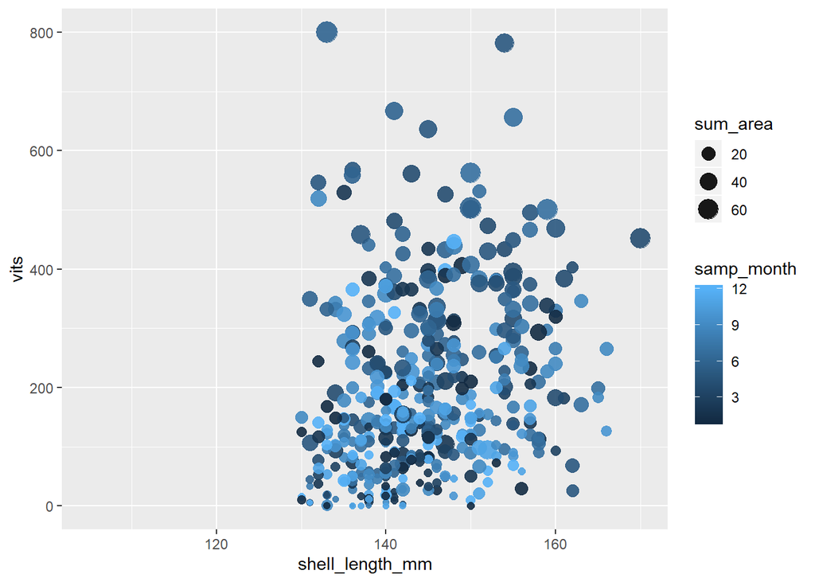

```r
stagedat %>% ggplot(aes(x=shell_length_mm, y=vits, colour=samp_month, size = sum_area)) +
geom_point(alpha = 0.9)
```

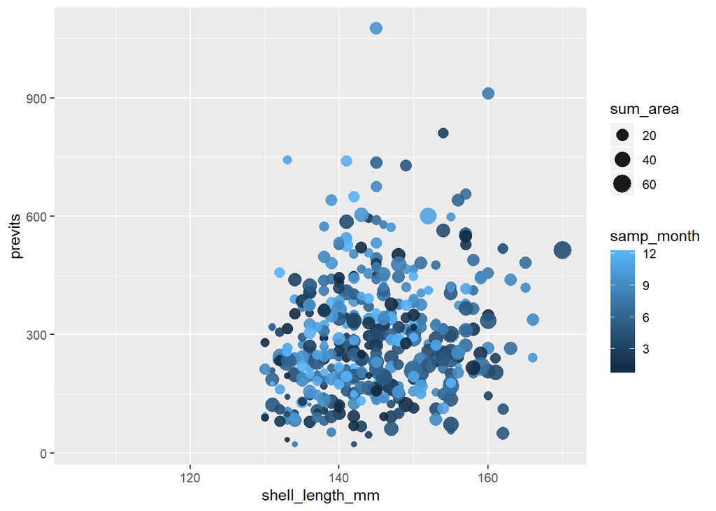

```r
stagedat %>% ggplot(aes(x=shell_length_mm, y=previts, colour=samp_month, size = sum_area)) +
geom_point(alpha = 0.9)
```

## Plot mean area of mature gonad for each gonad stage for month and year with error bars

[output not shown]

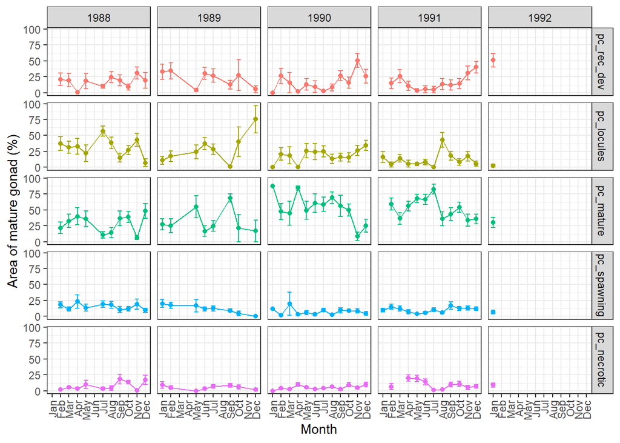

```r
## select gonad pc stage data and convert to long format
stagedat.1 <- stagedat %>%
 select(abalone_id,sample_year, sample_month, month.yr,
        pc_rec_dev, pc_locules, pc_mature, pc_spawning, pc_necrotic) %>%
 melt(id.vars = c('abalone_id', 'sample_year', 'sample_month', 'month.yr'))

## summarise gonad pc stage data for mean and se
stagedat.summ.long.1 <- stagedat.1 %>%
 group_by(sample_year, sample_month, month.yr, variable) %>%
 summarise(mean.pc = mean(value),
           se.pc = stderr(value))

## plot mean for each gonad stage for month and year including error bars
stagedat.summ.long.1 %>%
 ggplot(aes(x = sample_month, y = mean.pc, colour = variable, group = 1)) +
 geom_point()+
 geom_line() +
 geom_errorbar(aes(ymin = mean.pc - se.pc, ymax = mean.pc + se.pc), width = 0.5)+
 facet_grid(variable ~ sample_year) +
 ylab('Area of mature gonad (%)') +
 xlab('Month') +
 theme_bw() +
 theme(legend.position = 'none')+
 theme(axis.text.x = element_text(angle = 90, hjust = 1, vjust = 0.5))
```

## Plot mean pc of each gonad stage in each month (all years)

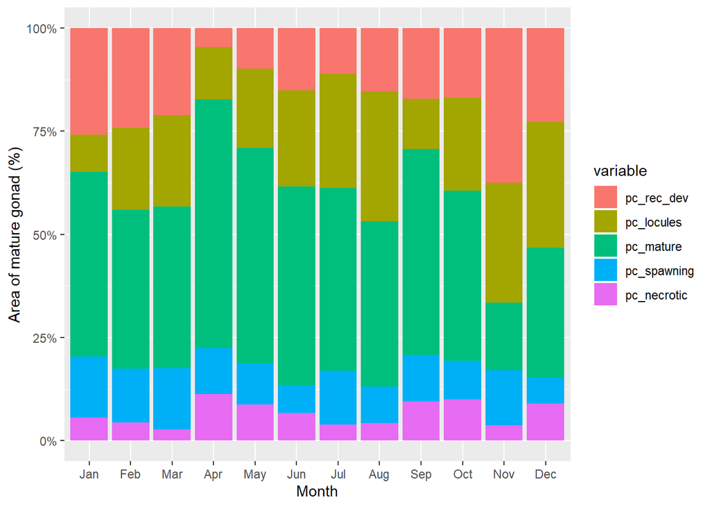

```r
stagedat.summ.long.1 %>%
 ggplot(aes(x = sample_month, y = mean.pc, fill = variable)) +
 geom_bar(position = 'fill', stat = 'identity') +
 scale_y_continuous(labels = scales::percent_format()) +
 ylab('Area of mature gonad (%)') +
 xlab('Month')
```

## plot mean pc of each gonand stage in each yr.month

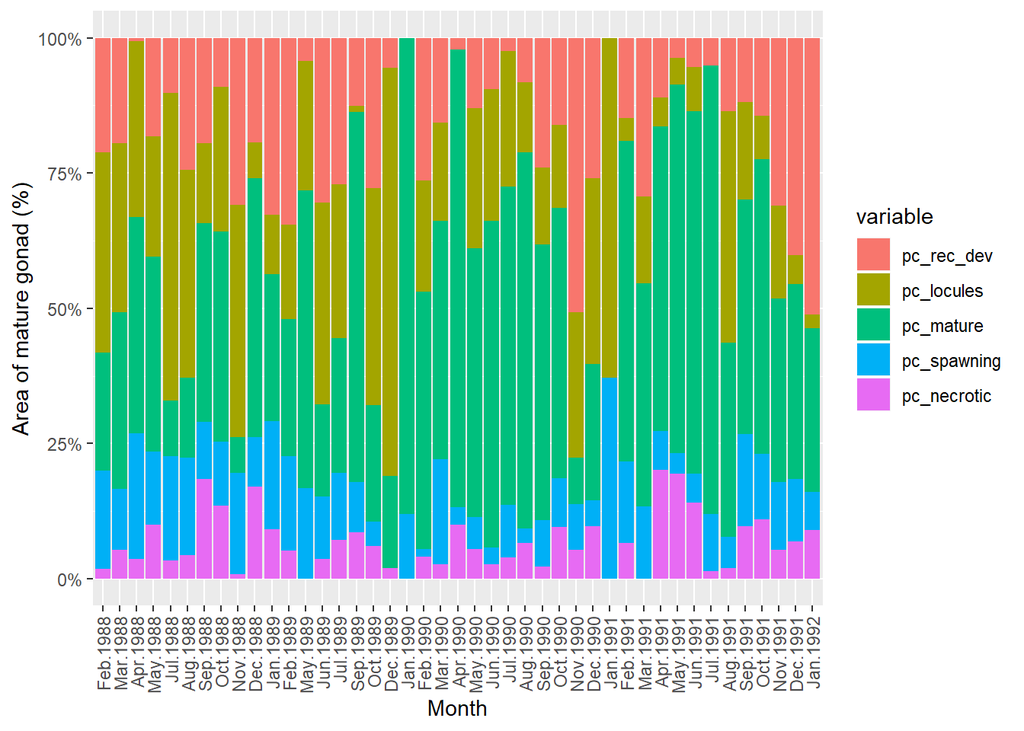

```r
stagedat.summ.long.1 %>%
 ggplot(aes(x = month.yr, y = mean.pc, fill = variable)) +
 geom_bar(position = 'fill', stat = 'identity') +
 scale_y_continuous(labels = scales::percent_format()) +
 ylab('Area of mature gonad (%)') +
 xlab('Month') +
 theme(axis.text.x = element_text(angle = 90, hjust = 1, vjust = 0.5))
```

## plot mean pc of vitellogenesis stage in each yr.month

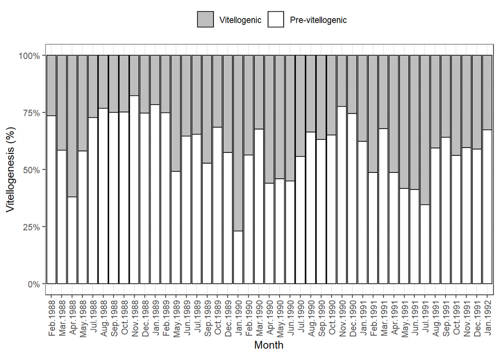

```r
# select vitellegenic data and convert to long format
vitsdat <- stagedat %>%
        select(abalone_id,sample_year, sample_month, month.yr,
               vits, previts) %>%
        melt(id.vars = c('abalone_id', 'sample_year', 'sample_month', 'month.yr'))

# summarise vitellegenic data for mean and se
vitsdat.summ <- vitsdat %>%
        filter(!is.na(value)) %>%
        group_by(sample_year, sample_month, month.yr, variable) %>%
        summarise(mean.vit = mean(value),
                  se.vit = stderr(value))

vitsdat.summ %>%
        ggplot(aes(x = month.yr, y = mean.vit, fill = variable)) +
        geom_bar(position = 'fill', stat = 'identity', colour = 'black') +
        scale_y_continuous(labels = scales::percent_format()) +
        ylab('Vitellogenesis (%)') +
        xlab('Month') +
        theme_bw() +
        theme(axis.text.x = element_text(angle = 90, hjust = 1, vjust = 0.5)) +
        theme(legend.title = element_blank(), legend.position = 'top') +
        scale_fill_manual(values = c('grey', 'white'), labels = c('Vitellogenic', 'Pre-vitellogenic'))
```